# Tutorial de knn en R: iris dataset

Flujo de trabajo paso a paso

Javier Álvarez Liébana https://javier-alvarez-liebana.github.io (Universidad Complutense de Madrid)  
2022-10-31

# Objetivo

El objetivo de este pequeño tutorial es saber aplicar un flujo de trabajo en el entorno `{tidymodels}` para poder implementar un algoritmo de clasificación knn en `R`. Puedes ver más detalles y funcionalidades en la web oficial del paquete: https://www.tidymodels.org/

## Paquetes necesarios

Necesitaremos los siguientes paquetes

- **Análisis exploratorio numérico**: paquete `{skimr}`
- **Depuración y preprocesamiento**: paquete `{tidyverse}`
- **Modelización**: paquete `{tidymodels}` para modelos

```r
# Borramos
rm(list = ls())

# Paquetes
library(skimr) # resumen numérico
library(tidymodels) # depuración datos
library(tidyverse) # modelos
```

# Datos

Los datos utilizados en este primer tutorial será el famoso dataset conocido como `iris`, que pasaremos a formato tibble nada más empezar

```r
iris <- as_tibble(iris)
glimpse(iris)
```

```
Rows: 150
Columns: 5
$ Sepal.Length <dbl> 5.1, 4.9, 4.7, 4.6, 5.0, 5.4, 4.6, 5.0, 4.4, 4.…
$ Sepal.Width  <dbl> 3.5, 3.0, 3.2, 3.1, 3.6, 3.9, 3.4, 3.4, 2.9, 3.…
$ Petal.Length <dbl> 1.4, 1.4, 1.3, 1.5, 1.4, 1.7, 1.4, 1.5, 1.4, 1.…
$ Petal.Width  <dbl> 0.2, 0.2, 0.2, 0.2, 0.2, 0.4, 0.3, 0.2, 0.2, 0.…
$ Species      <fct> setosa, setosa, setosa, setosa, setosa, setosa,…
```

## Análisis exploratorio (numérico)

Antes de tomar ninguna decisión con los datos lo primero que deberíamos hacer es **echar un vistazo numérico** a cómo se comportan las variables. Dado que vamos a clasificar, lo primero que deberíamos observar es como se distribuyen los niveles de nuestra variable objetivo.

```r
# Objetivo: predecir la especie de las plantas
iris %>% count(Species) %>% mutate(porc = 100 * n / sum(n))
```

```
# A tibble: 3 × 3
  Species        n  porc
  <fct>      <int> <dbl>
1 setosa        50  33.3
2 versicolor    50  33.3
3 virginica     50  33.3
```

Además con la función `skim()` del paquete `{skimr}` podemos **extraer algunas estadísticas básicas** de nuestros datos.

```r
# Resumen numérico
iris %>% skim()
```

Table 1: Data summary

| Name | Piped data |
| --- | --- |
| Number of rows | 150 |
| Number of columns | 5 |
| _______________________ |  |
| Column type frequency: |  |
| factor | 1 |
| numeric | 4 |
| ________________________ |  |
| Group variables | None |

**Variable type: factor**

| skim_variable | n_missing | complete_rate | ordered | n_unique | top_counts |
| --- | --- | --- | --- | --- | --- |
| Species | 0 | 1 | FALSE | 3 | set: 50, ver: 50, vir: 50 |

**Variable type: numeric**

| skim_variable | n_missing | complete_rate | mean | sd | p0 | p25 | p50 | p75 | p100 | hist |
| --- | --- | --- | --- | --- | --- | --- | --- | --- | --- | --- |
| Sepal.Length | 0 | 1 | 5.84 | 0.83 | 4.3 | 5.1 | 5.80 | 6.4 | 7.9 | ▆▇▇▅▂ |
| Sepal.Width | 0 | 1 | 3.06 | 0.44 | 2.0 | 2.8 | 3.00 | 3.3 | 4.4 | ▁▆▇▂▁ |
| Petal.Length | 0 | 1 | 3.76 | 1.77 | 1.0 | 1.6 | 4.35 | 5.1 | 6.9 | ▇▁▆▇▂ |
| Petal.Width | 0 | 1 | 1.20 | 0.76 | 0.1 | 0.3 | 1.30 | 1.8 | 2.5 | ▇▁▇▅▃ |

# Primer flujo de trabajo: knn

## Filosofía tidymodels

La idea detrás de `{tidymodels}` es **tratar por separado** la depuración y preparación de los datos, el modelo o paradigma de aprendizaje que se quiere aplicar, la optimización de los parámetros de dicho modelo, el ajuste, la evaluación y la predicción correspondiente, **creando un flujo de trabajo muy flexible**. La **filosofía es la misma que hay detrás de cocinar un plato**:

1. Primero **escribimos la receta**, una lista de pasos e instrucciones.
2. Después **preparamos la herramientas y utensilios para cocinar** (nuestro modelo).
3. Con la **receta + utensilios** podemos cocinar el plato muchas veces, con **distintos lotes de ingredientes (datos)**.

También podemos aplicar una receta distinta a distintos ingredientes, o incluso combinar partes de dos recetas. La idea es que tengamos guardado, y explícitamente detallado, cada uno de los componentes, para poder **combinarlos entre ellos**.

## Fase 1: muestreo y particiones

- Muestreo inicial.
- Partición train-test estratificada por la variable objetivo.

Una de las **primeras acciones a realizar** es un **muestreo inicial** de los datos, que en este caso no será necesario por la poca cantidad de registros disponibles, así que empezaremos directaemnte con una **partición train-test** estratificado por la variable `Species`: repartiremos en **70-30%** los datos **PERO asegurándonos de que la proporción de 0’s-1’s se preserva**.

```r
# Partición 70-30%: estratificada para que mantenga clases
# con el argumento pool podemos afinar mejor la estratificación
# para hacerla más exacta (por ejemplo, pool = 0.05)
iris_split <- initial_split(iris, strata = Species, prop = 0.7)
iris_split
```

```
<Analysis/Assess/Total>
<105/45/150>
```

En `iris_split` tenemos **guardada la información** de lo que queremos hacer cuando lo apliquemos, pero hasta que no se aplique no realiza ninguna acción.

```r
iris_train <- training(iris_split)
iris_test  <- testing(iris_split)

# Comprobamos estratos
iris_train %>% count(Species) %>% mutate(porc = 100 * n / sum(n))
```

```
# A tibble: 3 × 3
  Species        n  porc
  <fct>      <int> <dbl>
1 setosa        35  33.3
2 versicolor    35  33.3
3 virginica     35  33.3
```

```r
iris_test %>% count(Species) %>% mutate(porc = 100 * n / sum(n))
```

```
# A tibble: 3 × 3
  Species        n  porc
  <fct>      <int> <dbl>
1 setosa        15  33.3
2 versicolor    15  33.3
3 virginica     15  33.3
```

**Reminder**: los conjuntos que salen de `initial_split()` siguen a lo largo de todo el proceso (pero en conjuntos separados).

## Fase 2: exploración

### Resumen numérico: skim

Con `skim()`, del paquete `{skimr}`, podemos realizar un **primer análisis numérico** muy sencillo, haciendo uso de la función `skim()`

```r
library(skimr)
iris %>% skim()
```

Table 2: Data summary

| Name | Piped data |
| --- | --- |
| Number of rows | 150 |
| Number of columns | 5 |
| _______________________ |  |
| Column type frequency: |  |
| factor | 1 |
| numeric | 4 |
| ________________________ |  |
| Group variables | None |

**Variable type: factor**

| skim_variable | n_missing | complete_rate | ordered | n_unique | top_counts |
| --- | --- | --- | --- | --- | --- |
| Species | 0 | 1 | FALSE | 3 | set: 50, ver: 50, vir: 50 |

**Variable type: numeric**

| skim_variable | n_missing | complete_rate | mean | sd | p0 | p25 | p50 | p75 | p100 | hist |
| --- | --- | --- | --- | --- | --- | --- | --- | --- | --- | --- |
| Sepal.Length | 0 | 1 | 5.84 | 0.83 | 4.3 | 5.1 | 5.80 | 6.4 | 7.9 | ▆▇▇▅▂ |
| Sepal.Width | 0 | 1 | 3.06 | 0.44 | 2.0 | 2.8 | 3.00 | 3.3 | 4.4 | ▁▆▇▂▁ |
| Petal.Length | 0 | 1 | 3.76 | 1.77 | 1.0 | 1.6 | 4.35 | 5.1 | 6.9 | ▇▁▆▇▂ |
| Petal.Width | 0 | 1 | 1.20 | 0.76 | 0.1 | 0.3 | 1.30 | 1.8 | 2.5 | ▇▁▇▅▃ |

No parece que tengamos **problemas de codificación o rango**: los valores parecen valores permitidos según lo que representa la variable. Además tampoco tenemos **datos ausentes**, ya que `complete_rate` sale en todas 1 (`n_missing` está a cero). A la vista de los pequeños histogramas y los percentiles, no parece que tengamos **xcesivos valores atípicos (outliers)** (al menos muy evidentes, además la mediana y media se parecen entre sí). Quizás la **variable con mayor dispersión** sea `Petal.Length`.

Además todas las **variables predictoras son numéricas**: recordemos que para aplicar las métricas que conocemos en el KNN **necesitamos que sean numéricas**. En caso contrario nos tocaría **recategorizar**

### Balanceamiento de la variable objetivo

Una vez que hemos echado un vistazo a qué tenemos (de forma muy muy preliminar), lo primero a hacer en un **problema de clasificación** es determinar **cuál es nuestra variable objetivo**: nuestra variable $Y$ que vamos a clasificar, y que debe ser categórica. En este caso nuestra variable objetivo será la variable `Species`: vamos a intentar clasificar las flores, siendo la variable objetivo una variable que puede tomar 3 categorías (algo que podemos ver y resumir con `count()`).

```r
iris %>% count(Species)
```

```
# A tibble: 3 × 2
  Species        n
  <fct>      <int>
1 setosa        50
2 versicolor    50
3 virginica     50
```

### Importancia de las variables: objetivo vs predictores

Otra de las acciones clave será analizar cómo se **comporta la variable objetivo en función de los valores de cada variable**. ¿La longitud del sépalo media es similar en cada especie de planta? ¿Y la anchura del pétalo? Con ello podremos tener una idea preliminar de la **importancia de las variables** en la clasificación. Para ello combinaremos `group_by()` con `summarise()` (nos construye resúmenes numéricos, con la función que le pidamos).

```r
iris %>%
  group_by(Species) %>%
  summarise("mean_long_sep" = mean(Sepal.Length)) %>%
  ungroup()
```

```
# A tibble: 3 × 2
  Species    mean_long_sep
  <fct>              <dbl>
1 setosa              5.01
2 versicolor          5.94
3 virginica           6.59
```

Podemos hacer varias a la vez usando `across()`: le tendremos que indicar las variables a recorrer, y la función a aplicar en todas ellas.

```r
iris %>%
  group_by(Species) %>%
  summarise(mean = across(Sepal.Length:Petal.Width, mean)) %>%
  ungroup()
```

```
# A tibble: 3 × 2
  Species    mean$Sepal.Length $Sepal.Width $Petal.Length $Petal.Width
  <fct>                  <dbl>        <dbl>         <dbl>        <dbl>
1 setosa                  5.01         3.43          1.46        0.246
2 versicolor              5.94         2.77          4.26        1.33
3 virginica               6.59         2.97          5.55        2.03
```

Si nos fijamos en cada una de ellas:

- Las **variables relacionadas con el sépalo** no parece que cambien mucho de una especie a otra: seguramente **no sean influyentes]** en nuestra clasificación.
- Las **variables relacionadas con el pétalo** si parecen ser determinantes ya que la especie setosa tiene valores muy pequeños. Seguramente lo más complicado sea clasificar entre versicolor y virginica (se diferencia muy ligeramente)

### Colinealidad

Otro de los aspectos a considerar antes de tomar decisiones será **analizar la relación entre las variables]**, empezando por la posible relación lineal, calculando la matriz de correlaciones con las herramientas de la librería `{corrr}`. **Importante**: solo podemos pasarle las variables numéricas de la tabla.

```r
library(corrr)
correlate(iris %>% select(where(is.numeric)))
```

```
# A tibble: 4 × 5
  term         Sepal.Length Sepal.Width Petal.Length Petal.Width
  <chr>               <dbl>       <dbl>        <dbl>       <dbl>
1 Sepal.Length       NA          -0.118        0.872       0.818
2 Sepal.Width        -0.118      NA           -0.428      -0.366
3 Petal.Length        0.872      -0.428       NA           0.963
4 Petal.Width         0.818      -0.366        0.963      NA
```

La matriz de correlaciones será **siempre simétrica** y en la diagonal siempre será 1 (podemos indicarle que queremos que nos muestre con el argumento `diagonal = ...`). La matriz de correlaciones será **siempre simétrica** y en la diagonal siempre será 1 (podemos indicarle que queremos que nos muestre con el argumento `diagonal = ...`)

```r
correlate(iris %>% select(where(is.numeric)), diagonal = "*")
```

```
# A tibble: 4 × 5
  term         Sepal.Length       Sepal.Width        Petal.L…¹ Petal…²
  <chr>        <chr>              <chr>              <chr>     <chr>
1 Sepal.Length *                  -0.117569784133002 0.871753… 0.8179…
2 Sepal.Width  -0.117569784133002 *                  -0.42844… -0.366…
3 Petal.Length 0.871753775886583  -0.42844010433054  *         0.9628…
4 Petal.Width  0.817941126271576  -0.366125932536439 0.962865… *
# … with abbreviated variable names ¹Petal.Length, ²Petal.Width
```

También podemos mostrarla algo más estética **redondeando los valores** con `fashion()`

```r
correlate(iris %>% select(where(is.numeric))) %>% fashion()
```

```
          term Sepal.Length Sepal.Width Petal.Length Petal.Width
1 Sepal.Length                     -.12          .87         .82
2  Sepal.Width         -.12                     -.43        -.37
3 Petal.Length          .87        -.43                      .96
4  Petal.Width          .82        -.37          .96
```

Incluso visualizarla con el paquete `{corrplot}`

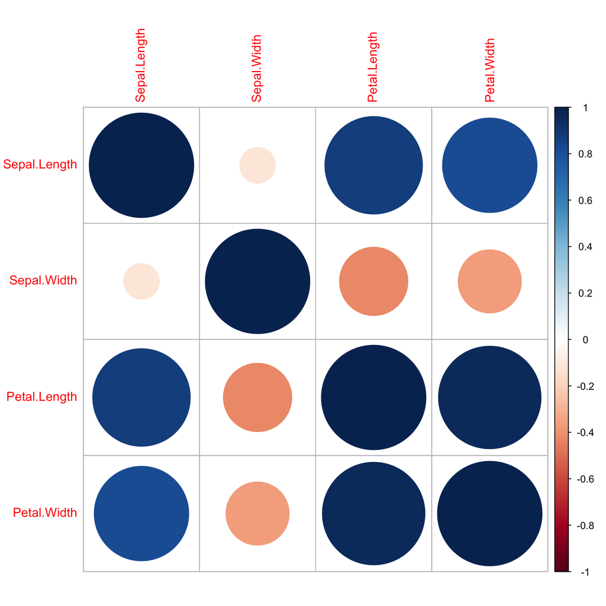

```r
library(corrplot)
cor_matrix <- cor(iris %>% select(where(is.numeric)))
corrplot(cor_matrix)
```

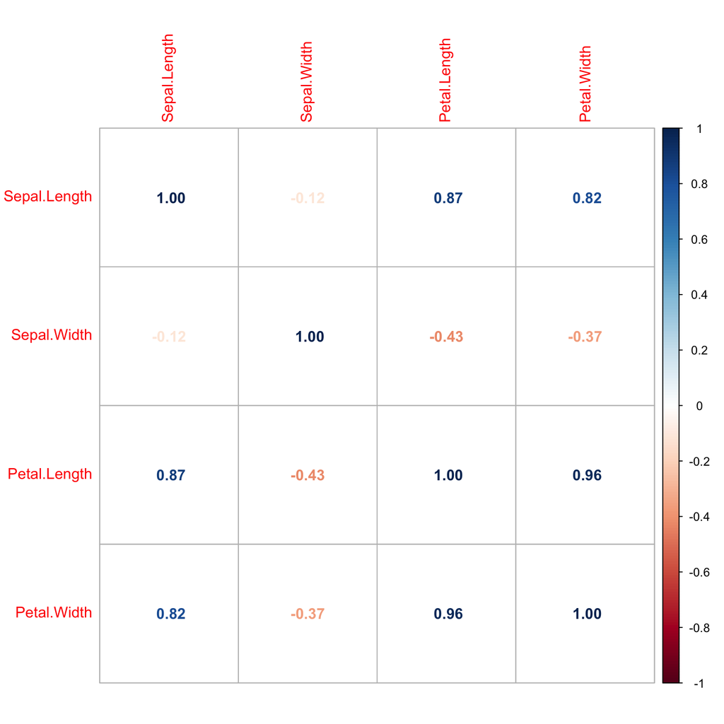

```r
corrplot(cor_matrix, method = "number")
```

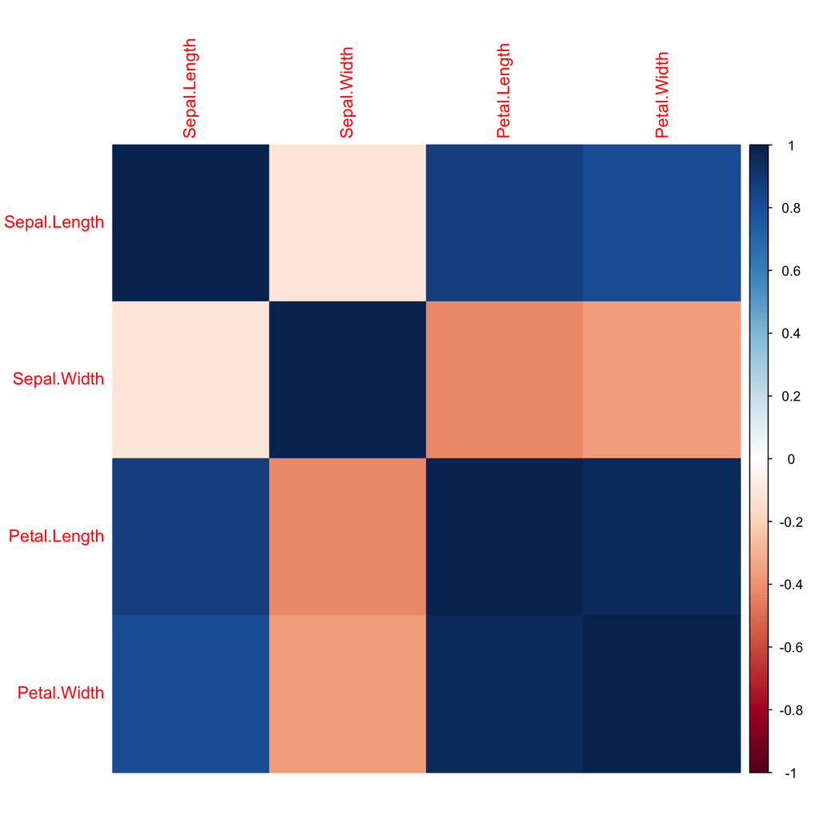

```r
corrplot(cor_matrix, method = "color")
```

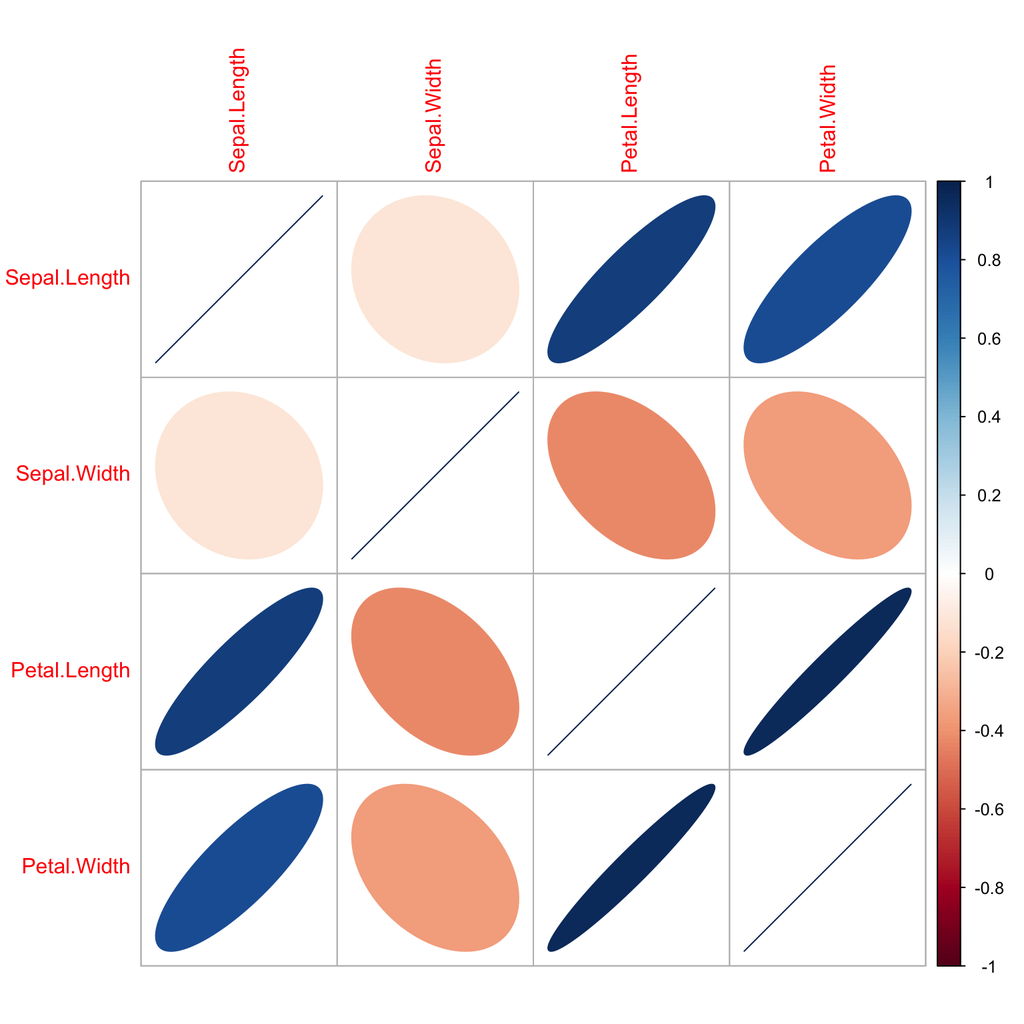

```r
corrplot(cor_matrix, method = "ellipse")
```

En este caso tenemos dos variables muy correlacionadas: `Petal.Length` y `Petal.Width`, con una correlación de casi 1, lo que nos indica que nos van a aportar **información redundante** una de la otra, provocando **problemas de colinealidad**.

Nuestro caso ideal sería aquel en el que todas fuesen independientes (o al menos incorreladas entre sí, sin dependencia lineal), para **maximizar la información de los datos**. Si dos variables nos aportan lo mismo, una seguramente sobre (ya que solo nos va a aportar ruido). Veremos más adelante otras herramientas para cuantificar la dependencia (no solo lineal, y no solo de variables cuanti)

También aprenderemos a **visualizar los datos**, un paso CLAVE en el análisis exploratorio y la depuración, pero más adelante.

## Fase 3: modificación

- Asignar roles
- Recategorizar
- Tratamiento de outliers
- Tratamiento de datos ausentes
- Tratamiento de fechas
- Selección de variables
- Filtro de correlación
- Filtro de varianza cero
- Estandarización por rango y/o normalización (tipificación)

La lista de arriba son **algunas de las opciones que quizás querramos hacer** con nuestras variables antes de poder aplicar un modelo. Todo ello lo incluiremos en una recta, y vamos a empezar en este primer tutorial por una **receta sencilla**

### Definición de la recta

Con la información obtenida de la anterior fase, en la **fase de modificación o depuración** es donde tendremos que tomar decisiones para **preparar nuestros datos** de manera adecuada. Y para ello será **fundamental conocer el algoritmo** que vamos a aplicar.

El primer paso en nuestra receta será indicarle en `recipe()` los **datos** y la **«fórmula»** de nuestro modelo (en nuestro caso le indicaremos que vamos la objetivo será `Species` frente al resto de predictoras numéricas). La receta **guardará los roles**: 4 predictoras y 1 objetivo

```r
iris_rec <-
  # Fórmula y datos
  recipe(data = iris_train, Species ~ .)
iris_rec
```

```
Recipe

Inputs:

      role #variables
   outcome          1
 predictor          4
```

```r
iris_rec %>% summary()
```

```
# A tibble: 5 × 4
  variable     type    role      source
  <chr>        <chr>   <chr>     <chr>
1 Sepal.Length numeric predictor original
2 Sepal.Width  numeric predictor original
3 Petal.Length numeric predictor original
4 Petal.Width  numeric predictor original
5 Species      nominal outcome   original
```

### Asignar roles

Dicha receta la hemos llamado `iris_rec` ya que **podemos querer aplicarla** para preprocesar antes de aplicar distintos modelos de clasificación (árboles, knn, etc): aunque el modelo sea distinto, **la receta previa puede ser la misma**. Vamos a complicar un poco nuestra receta **indicándole algunos roles especiales en nuestros datos** (los roles son fundamentales ya que dependiendo del rol asignado podremos «llamar» a nuestras variables).

- `update_role()`: actualizar el rol de la variable (lo machaca el que existiese).
- `add_role()`: añadir rol a la variable (amén de los que ya tuviese asignados).
- `remove_role()`: eliminar rol.

Dado que el tratamiento de outliers lo estamos haciendo de manera distinta en las variables de sépalo que en las de pétalo, lo primero que haremos es **asignar** roles (sin eliminar el rol de predictor que ya tiene, así que lo haremos con `add_role()`)

```r
iris_rec <-
  iris_rec %>%
  # Roles
  add_role(starts_with("Sepal"), new_role = "sepal") %>%
  add_role(starts_with("Petal"), new_role = "petal")
iris_rec
```

```
Recipe

Inputs:

      role #variables
   outcome          1
     petal          2
 predictor          4
     sepal          2
```

```r
iris_rec %>% summary()
```

```
# A tibble: 9 × 4
  variable     type    role      source
  <chr>        <chr>   <chr>     <chr>
1 Sepal.Length numeric predictor original
2 Sepal.Length numeric sepal     original
3 Sepal.Width  numeric predictor original
4 Sepal.Width  numeric sepal     original
5 Petal.Length numeric predictor original
6 Petal.Length numeric petal     original
7 Petal.Width  numeric predictor original
8 Petal.Width  numeric petal     original
9 Species      nominal outcome   original
```

En este caso además todas las variables son numéricas y no hay aparentemente problemas de codificación. Fíjate que **nuestra receta no ha realizado ningún paso**, es algo así como la **receta escrita que tenemos guardada en un cajón** para preparar un plato: la receta por sí sola no se pone a cocinarte menús, simplemente es una lista de instrucciones, lista para cuando la necesites. Las funciones que empiezan por `step_` tienen implementadas muchas de las funcionalidades que podemos realizar en depuración con `{tidyverse}`. La diferencia al incluirlo en la receta es que **se ejecutará cada vez que dicha receta se aplique (tanto a train como a test)**.

### Tratamiento de outliers (tidyverse)

Una de las partes más importantes de la fase de exploración y modificación es la **detección de outliers**, pudiendo tener diferentes definiciones de valor atípico:

#### Respecto a media

- **Atípico respecto a media**: será un dato muy alejado de la **media de la variable**. ¿Cuánto de alejado? Una definición habitual es definir un dato atípico como aquel que se aleja de la media $k$ veces la desviación típica (un valor habitual es $k = 2.5$).

$$x_i > \overline{x} + k* s_{j} \quad \text{ o bien } \quad x_i < \overline{x} - k *s_{j}$$

Dicha definición de atípico solo tendrá sentido cuando la **media sea representativa** de tu distribución, es decir, siempre y cuando tengamos cierta simetría (ya que sino, la media al ser poco robusta se perturbará fácilmente).

Para detectarlos usaremos el paquete `{outliers}` y su función `scores()`, que nos dará en cada caso una **“puntuación” de cada observación**. En caso de que queramos **detectarlos respecto a la media**, le indicaremos que `type = "z"`: nos devolverá precisamente el valor $k$ (si aplicamos valor absoluto), ya que hará cada observación menos la media y la dividirá entre la desviación típica.

```r
library(outliers)
abs(scores(c(1, -1, 0, 5, 2, 1.5, 0.5, -0.3, 0, 2, 1.7, 0.2, -0.8), type = "z"))
```

```
 [1] 0.05794825 1.19759725 0.56982450 2.56903925 0.68572100 0.37183463
 [7] 0.25593812 0.75815632 0.56982450 0.68572100 0.49738918 0.44426995
[13] 1.07204270
```

De forma que podamos detectar muy fácil los outliers en función de los estrictos que queramos ser con ese $k$. El tipo `type = "chisq"` nos hace algo parecido pero elevando las desviaciones al cuadrado y diviendo por la varianza.

En el caso de nuestros datos, usaremos $k = 2.5$, y detectaremos aquellos datos que son outliers para luego pasarlos a un **valor ausente**.

```r
iris_na_outliers <-
  iris %>%
  mutate(Sepal.Width =
           ifelse(abs(scores(Sepal.Width, type = "z")) > 2.5,
                  NA, Sepal.Width))
iris_na_outliers
```

```
# A tibble: 150 × 5
   Sepal.Length Sepal.Width Petal.Length Petal.Width Species
          <dbl>       <dbl>        <dbl>       <dbl> <fct>
 1          5.1         3.5          1.4         0.2 setosa
 2          4.9         3            1.4         0.2 setosa
 3          4.7         3.2          1.3         0.2 setosa
 4          4.6         3.1          1.5         0.2 setosa
 5          5           3.6          1.4         0.2 setosa
 6          5.4         3.9          1.7         0.4 setosa
 7          4.6         3.4          1.4         0.3 setosa
 8          5           3.4          1.5         0.2 setosa
 9          4.4         2.9          1.4         0.2 setosa
10          4.9         3.1          1.5         0.1 setosa
# … with 140 more rows
# ℹ Use `print(n = ...)` to see more rows
```

```r
iris_na_outliers %>% filter(is.na(Sepal.Width))
```

```
# A tibble: 2 × 5
  Sepal.Length Sepal.Width Petal.Length Petal.Width Species
         <dbl>       <dbl>        <dbl>       <dbl> <fct>
1          5.7          NA          1.5         0.4 setosa
2          5.5          NA          1.4         0.2 setosa
```

Tras ello tendremos **dos opciones**: **eliminar** dichas observaciones o **imputar la media** sin los ausentes (dado que los hemos detectado con la media)

```r
# opción 1
iris_outliers <-
  iris_na_outliers %>%
  mutate(Sepal.Width =
           ifelse(is.na(Sepal.Width), mean(Sepal.Width, na.rm = TRUE), Sepal.Width))
```

```r
# opción 2
iris_outliers <- iris_na_outliers %>% drop_na(Sepal.Width)
```

Si queremos hacer esto con varias variables a la vez, tendremos que usar de nuevo `across()`

```r
iris_na_outliers <-
  iris %>%
  mutate(across(Sepal.Length:Petal.Width,
                function(x) { ifelse(abs(scores(x, type = "z")) > 2.5, NA, Sepal.Length) }))
```

Con `if_any()` dentro del `filter()` podemos mostrar todo los registros detectados como outlier en alguna variable.

```r
iris_na_outliers %>% filter(if_any(Sepal.Length:Petal.Width, is.na))
```

```
# A tibble: 2 × 5
  Sepal.Length Sepal.Width Petal.Length Petal.Width Species
         <dbl>       <dbl>        <dbl>       <dbl> <fct>
1          5.7          NA          5.7         5.7 setosa
2          5.5          NA          5.5         5.5 setosa
```

Tras su detección y análisis podemos o imputarles a todos la media (de la variable en cuestión) o eliminarlos.

```r
# opción 1
iris_outliers <-
  iris_na_outliers %>%
  mutate(across(Sepal.Length:Petal.Width,
                function(x) { ifelse(is.na(x), mean(x, na.rm = TRUE), x) }))
```

```r
# opción 2
iris_outliers <-
  iris_na_outliers %>% drop_na()
```

#### Respecto a mediana

- **Atípico respecto a mediana**: será un dato muy alejado de la **mediana de la variable**. ¿Cuánto de alejado? Una definición habitual (conocido como **filtro de Hampel**) es definir un dato atípico como aquel que se aleja de la mediana $k$ veces la mediana de las desviaciones absolutas (conocida como $MAD = Me \left(\left| x_i - Me_x \right| \right)$). Un valor habitual es $k = 3$.

$$x_i > Me_{x} + k*MAD\quad \text{ o bien } \quad x_i< Me_{x} - k*MAD$$

Para ello nos bastará usar `scores()` con `type = "mad"` (y nos devolverá de nuevo ese $k$).

```r
abs(scores(c(1, -1, 0, 5, 2, 1.5, 0.5, -0.3, 0, 2, 1.7, 0.2, -0.8), type = "mad"))
```

```
 [1] 0.3372454 1.0117361 0.3372454 3.0352084 1.0117361 0.6744908
 [7] 0.0000000 0.5395926 0.3372454 1.0117361 0.8093889 0.2023472
[13] 0.8768380
```

El **valor a imputar sería la mediana**

#### Respecto a percentiles

- **Atípico respecto a percentiles**: será un dato muy alejado de los **cuartiles de la variable**. ¿Cuánto de alejado? Una definición habitual es definir un dato atípico como aquel que se aleja de los cuartiles 1 y 3 (percentiles 25 y 75) $k$ veces el rango intercuartílico ($IQR = Q_3 - Q_1$). Un valor habitual es $k = 1.5$).

$$x_i > Q_3 + k* IQR \quad \text{ o bien } \quad x_i < Q_1 - k*IQR$$

Para ello nos bastará usar `scores()` con `type = "iqr"` (y nos devolverá de nuevo ese $k$, siendo $k = 0$ para lo que esté dentro del IQR).

```r
abs(scores(c(1, -1, 0, 5, 2, 1.5, 0.5, -0.3, 0, 2, 1.7, 0.2, -0.8), type = "iqr"))
```

```
 [1] 0.0000000 0.5882353 0.0000000 1.9411765 0.1764706 0.0000000
 [7] 0.0000000 0.1764706 0.0000000 0.1764706 0.0000000 0.0000000
[13] 0.4705882
```

El **valor a imputar sería la mediana**

#### Métodos basados en inferencia

Existen otros procedimientos **basados en inferencia estadística** (muchos de ellos en el paquete `{outliers}`)

- **Tests de Grubbs y Dixon**: ambos test nos permiten **detectar si el valor más alto (o bajo)** de una varibale es un outlier, pudiendo detectar un solo outlier en cada iteración (en caso de detectarlo, deberíamos tratarlo y volver a ejecutar el test)

$\mathcal{H}_0: \text{valor más alto/bajo no es outlier}$

$\mathcal{H}_1: \text{ valor más alto/bajo sí es outlier}$

El test de Dixon (basado en una ordenación) suele funcionar mejor cuando tenemos poca muestra que el test de Grubbs (basado en la media).

📚 Ver más documentación de su funcionamiento en https://www.itl.nist.gov/div898/handbook/eda/section3/eda35h1.htm y https://www.statisticshowto.com/dixons-q-test/

Por ejemplo, para el de Dixon existe `dixon.test()`

```r
x <- c(1, -1, 0, 5, 2, 1.5, 0.5, -0.3, 0, 2, 1.7, 0.2, -0.8)
dixon.test(x, opposite = TRUE) # valor más bajo
```

```
    Dixon test for outliers

data:  x
Q = 0.23333, p-value = 0.8072
alternative hypothesis: lowest value -1 is an outlier
```

```r
x <- c(1, -1, 0, 5, 2, 1.5, 0.5, -0.3, 0, 2, 1.7, 0.2, -0.8)
dixon.test(x, opposite = FALSE) # valor más alto
```

```
    Dixon test for outliers

data:  x
Q = 0.51724, p-value = 0.1055
alternative hypothesis: highest value 5 is an outlier
```

- **Test de Rosner**: al contrario que los anteriores, nos permite **detectar varios outliers** a la vez, especialmente diseñado para evitar que un valor atípico nos perturbe tanto que nos enmascare otro (basado en la media). Podemos ejecutarlo con la función `rosnerTest()` del paquete `{EnvStats}`.

**IMPORTANTE**: la detección de outliers deberá combinar el análisis numérico y la visualización.

📚 Ver más documentación de su funcionamiento en https://vsp.pnnl.gov/help/vsample/rosners_outlier_test.htm

### Tratamiento de outliers (tidymodels)

Lo que haremos a continuación será **detectar outliers** (transformando dichos outliers a `NA`)

```r
iris_rec <-
  iris_rec %>%
  # Detectar outliers
  step_mutate(across(starts_with("Sepal"), function(x) { ifelse(abs(scores(x, type = "z")) > 2.5, NA, x) }),
              across(starts_with("Petal"), function(x) { ifelse(abs(scores(x, type = "mad")) > 3, NA, x) }))

iris_rec
```

```
Recipe

Inputs:

      role #variables
   outcome          1
     petal          2
 predictor          4
     sepal          2

Operations:

Variable mutation for across(starts_with("Sepal"), fun...
```

```r
iris_rec %>% summary()
```

```
# A tibble: 9 × 4
  variable     type    role      source
  <chr>        <chr>   <chr>     <chr>
1 Sepal.Length numeric predictor original
2 Sepal.Length numeric sepal     original
3 Sepal.Width  numeric predictor original
4 Sepal.Width  numeric sepal     original
5 Petal.Length numeric predictor original
6 Petal.Length numeric petal     original
7 Petal.Width  numeric predictor original
8 Petal.Width  numeric petal     original
9 Species      nominal outcome   original
```

### Tratamiento de ausentes

- `step_impute_mean()`, `step_impute_median()` y `step_impute_mode()`: imputamos por media, mediana o moda.
- `step_impute_knn()`: usaremos un knn previo para imputar los ausentes.
- `step_impute_bag()`: usaremos un árbol o conjunto de árboles para imputar los ausentes.
- `step_impute_linear()`: usaremos una regresión lineal para imputar ausentes

```r
iris_rec <-
  iris_rec %>%
  # Imputar ausentes
  step_impute_mean(has_role("sepal")) %>%
  step_impute_median(has_role("petal"))

iris_rec
```

```
Recipe

Inputs:

      role #variables
   outcome          1
     petal          2
 predictor          4
     sepal          2

Operations:

Variable mutation for across(starts_with("Sepal"), fun...
Mean imputation for has_role("sepal")
Median imputation for has_role("petal")
```

```r
iris_rec %>% summary()
```

```
# A tibble: 9 × 4
  variable     type    role      source
  <chr>        <chr>   <chr>     <chr>
1 Sepal.Length numeric predictor original
2 Sepal.Length numeric sepal     original
3 Sepal.Width  numeric predictor original
4 Sepal.Width  numeric sepal     original
5 Petal.Length numeric predictor original
6 Petal.Length numeric petal     original
7 Petal.Width  numeric predictor original
8 Petal.Width  numeric petal     original
9 Species      nominal outcome   original
```

Fíjate la **utilidad de los roles**: con `has_role()` podemos indicarle a qué variables aplicar la acción.

### Filtro de correlación

Para tratar los **problemas de colinealidad** usaremos directamente `step_corr()`, al que le tendremos que pasar un umbral en `threshold`: se queda solo con una variable de todo par de variables cuya **correlación en valor absoluto supere el umbral** (en este caso usaremos `all_numeric_predictors()` para considerar solo las predictoras numéricas)

```r
iris_rec <-
  iris_rec %>%
  # Filtro de correlación
  step_corr(all_numeric_predictors(), threshold = 0.9)

iris_rec
```

```
Recipe

Inputs:

      role #variables
   outcome          1
     petal          2
 predictor          4
     sepal          2

Operations:

Variable mutation for across(starts_with("Sepal"), fun...
Mean imputation for has_role("sepal")
Median imputation for has_role("petal")
Correlation filter on all_numeric_predictors()
```

```r
iris_rec %>% summary()
```

```
# A tibble: 9 × 4
  variable     type    role      source
  <chr>        <chr>   <chr>     <chr>
1 Sepal.Length numeric predictor original
2 Sepal.Length numeric sepal     original
3 Sepal.Width  numeric predictor original
4 Sepal.Width  numeric sepal     original
5 Petal.Length numeric predictor original
6 Petal.Length numeric petal     original
7 Petal.Width  numeric predictor original
8 Petal.Width  numeric petal     original
9 Species      nominal outcome   original
```

### Normalización

Por último, dado que el knn es un **algoritmo que usa una distancia (geométrica en nuestro caso)**, necesitamos que **todas las variables tengan el mismo peso inicial**, así que vamos a **estandarizar las numéricas por rango** con `step_range()` (siempre entre 0 y 1, aunque podríamos asignarle otro rango dando valores a `max` y `min`). Con `step_normalize()` normalizaríamos (media nula y varianza unitaria).

$$x_{range} = \frac{x - min(x)}{max(x) - min(x)}, \quad x_{normalize} = \frac{x - \overline{x}}{s_{x}}$$

Lo haremos con `step_range()` para que nos **normalice por rango** las variables predictoras que sean numéricas.

```r
iris_rec <-
  iris_rec %>%
  # Normalizar por rango
  step_range(all_numeric_predictors())

iris_rec
```

```
Recipe

Inputs:

      role #variables
   outcome          1
     petal          2
 predictor          4
     sepal          2

Operations:

Variable mutation for across(starts_with("Sepal"), fun...
Mean imputation for has_role("sepal")
Median imputation for has_role("petal")
Correlation filter on all_numeric_predictors()
Range scaling to [0,1] for all_numeric_predictors()
```

```r
iris_rec %>% summary()
```

```
# A tibble: 9 × 4
  variable     type    role      source
  <chr>        <chr>   <chr>     <chr>
1 Sepal.Length numeric predictor original
2 Sepal.Length numeric sepal     original
3 Sepal.Width  numeric predictor original
4 Sepal.Width  numeric sepal     original
5 Petal.Length numeric predictor original
6 Petal.Length numeric petal     original
7 Petal.Width  numeric predictor original
8 Petal.Width  numeric petal     original
9 Species      nominal outcome   original
```

### Filtro de varianza cero

Por último añadiremos siempre un último **filtro de cero varianza** para que nos elimine las variables con varianza constante.

```r
iris_rec <-
  iris_rec %>%
  # Filtro de cero varianza
  step_zv(all_predictors())

iris_rec
```

```
Recipe

Inputs:

      role #variables
   outcome          1
     petal          2
 predictor          4
     sepal          2

Operations:

Variable mutation for across(starts_with("Sepal"), fun...
Mean imputation for has_role("sepal")
Median imputation for has_role("petal")
Correlation filter on all_numeric_predictors()
Range scaling to [0,1] for all_numeric_predictors()
Zero variance filter on all_predictors()
```

```r
iris_rec %>% summary()
```

```
# A tibble: 9 × 4
  variable     type    role      source
  <chr>        <chr>   <chr>     <chr>
1 Sepal.Length numeric predictor original
2 Sepal.Length numeric sepal     original
3 Sepal.Width  numeric predictor original
4 Sepal.Width  numeric sepal     original
5 Petal.Length numeric predictor original
6 Petal.Length numeric petal     original
7 Petal.Width  numeric predictor original
8 Petal.Width  numeric petal     original
9 Species      nominal outcome   original
```

### Receta final: horneado (bake)

La receta final completa sería por tanto la siguiente

```r
iris_rec <-
  # Fórmula y datos
  recipe(data = iris_train, Species ~ .) %>%
  # Roles
  add_role(starts_with("Sepal"), new_role = "sepal") %>%
  add_role(starts_with("Petal"), new_role = "petal") %>%
  # Detectar outliers
  step_mutate(across(starts_with("Sepal"), function(x) { ifelse(abs(scores(x, type = "z")) > 2.5, NA, x) }),
              across(starts_with("Petal"), function(x) { ifelse(abs(scores(x, type = "mad")) > 3, NA, x) })) %>%
  # Imputar ausentes
  step_impute_mean(has_role("sepal")) %>%
  step_impute_median(has_role("petal")) %>%
  # Filtro de correlación
  step_corr(all_numeric_predictors(), threshold = 0.9) %>%
  # Normalizar por rango
  step_range(all_numeric_predictors()) %>%
  # Filtro de cero varianza
  step_zv(all_predictors())

iris_rec
```

```
Recipe

Inputs:

      role #variables
   outcome          1
     petal          2
 predictor          4
     sepal          2

Operations:

Variable mutation for across(starts_with("Sepal"), fun...
Mean imputation for has_role("sepal")
Median imputation for has_role("petal")
Correlation filter on all_numeric_predictors()
Range scaling to [0,1] for all_numeric_predictors()
Zero variance filter on all_predictors()
```

```r
iris_rec %>% summary()
```

```
# A tibble: 9 × 4
  variable     type    role      source
  <chr>        <chr>   <chr>     <chr>
1 Sepal.Length numeric predictor original
2 Sepal.Length numeric sepal     original
3 Sepal.Width  numeric predictor original
4 Sepal.Width  numeric sepal     original
5 Petal.Length numeric predictor original
6 Petal.Length numeric petal     original
7 Petal.Width  numeric predictor original
8 Petal.Width  numeric petal     original
9 Species      nominal outcome   original
```

Una vez que la **receta está diseñada** una buena práctica para evitar errores es comprobar que se ejecuta correctamente (y qué no sucede nada raro) en el conjunto de entrenamiento. Tras escribir la receta vamos a **prepararla** (con `prep()`) y a **hornear los datos** con `bake()`: para hornearla en el conjunto de train, basta con poner `new_data = NULL`.

```r
# Aplicada a train
bake(iris_rec %>% prep(), new_data = NULL)
```

```
# A tibble: 105 × 4
   Sepal.Length Sepal.Width Petal.Width Species
          <dbl>       <dbl>       <dbl> <fct>
 1       0.167        0.421      0.0417 setosa
 2       0.111        0.526      0.0417 setosa
 3       0.0833       0.474      0.0417 setosa
 4       0.194        0.737      0.0417 setosa
 5       0.306        0.895      0.125  setosa
 6       0.194        0.632      0.0417 setosa
 7       0.0278       0.368      0.0417 setosa
 8       0.167        0.474      0      setosa
 9       0.306        0.789      0.0417 setosa
10       0.139        0.421      0      setosa
# … with 95 more rows
# ℹ Use `print(n = ...)` to see more rows
```

```r
# Aplicada a test
bake(iris_rec %>% prep(), new_data = iris_test)
```

```
# A tibble: 45 × 4
   Sepal.Length Sepal.Width Petal.Width Species
          <dbl>       <dbl>       <dbl> <fct>
 1       0.222        0.684      0.0417 setosa
 2       0.0833       0.632      0.0833 setosa
 3       0.139        0.632      0.0417 setosa
 4       0.222        0.684      0.0833 setosa
 5       0.389        0.842      0.0833 setosa
 6       0.306        0.632      0.0417 setosa
 7       0.222        0.789      0.125  setosa
 8       0.222        0.579      0.167  setosa
 9       0.194        0.632      0.125  setosa
10       0.25         0.632      0.0417 setosa
# … with 35 more rows
# ℹ Use `print(n = ...)` to see more rows
```

Nuestra receta, aplicada a nuestros ingredientes, está lista. Este «horneado» con `bake()` solo lo necesitamos **si queremos ya aplicar la receta a nuestros datos**. Nosotros, al añadir ahora un modelo de clasificación, **incluiremos la receta en un flujo de trabajo**.

## Fase 4: modelización

### Definición del modelo (utensilios de cocina)

Una vez que tenemos nuestra lista de instrucciones escrita, lo siguiente que haríamos al **cocinar un plato** es buscar los utensilios necesarios: cuchillos, cacerolas, batidora, etc. En nuestro caso los **utensilios serán nuestro modelo (en este caso de clasificación)**, con `nearest_neighbor()` (echa un vistazo a los modelos del paquete `{parsnip}`). La idea del **algoritmo de los k-vecinos (knn)** es muy similar al **proceso que seguiríamos para decidir si vemos o no una película**: preguntaríamos a un número de conocidos (parámetro k), decidiríamos si ir o no en función de la mayoría de opiniones, y no trataríamos todas las opiniones por igual (dependiendo de la cercanía o afinidad, ponderaríamos las opiniones).

En `nearest_neighbor()` especificaremos los siguientes argumentos (de momento):

- `mode`: admite dos opciones, `mode = "classification"` o `mode = "regression"` (en nuestro caso `mode = "classification"`).
- `neighbors`: el número de vecinos `k` que consideramos como entorno de vecindad para asignar una categoría a los datos.
- `weight_func`: función (kernel) para promedir distancias (`weight_func = "inv"` nos promedia por el inverso de la distancia, vecinos más alejados valen menos en la asignación; ver opciones en https://epub.ub.uni-muenchen.de/1769/)
- `dist_power`: número $r$ de la distancia de Minkowski ($r = 2$ es la distancia euclídea)

$$D_{Minkow}(\boldsymbol{x}, \boldsymbol{y}) = \left(\sum_{i=1}^{p} \left|x_i - y_i \right|^r\right)^{1/r}, \quad \boldsymbol{x} = \left(x_1, \ldots, x_p\right),~ \boldsymbol{y} = \left(y_1, \ldots, y_p \right)$$

Con `set_engine("kknn")` le **especificaremos en concreto el «motor» (el paquete)** que contiene las herramientas matemáticas necesarias con el que realizaremos el ajuste.

```r
knn_model <-
  nearest_neighbor(mode = "classification", neighbors = 10,
                   weight_func = "inv", dist_power = 2) %>%
  set_engine("kknn") # el «motor» que realiza el ajuste
knn_model
```

```
K-Nearest Neighbor Model Specification (classification)

Main Arguments:
  neighbors = 10
  weight_func = inv
  dist_power = 2

Computational engine: kknn
```

### Flujo de trabajo

Llegados a este punto tenemos

- Tenemos una **receta para preprocesar los datos**, una lista de instrucciones.
- Tenemos los **utensilios (modelo)**.
- Tenemos los **ingredientes (datos) ya preparados** (muestreo, partición, etc).

Con dichos ingredientes podemos crear ya un **flujo de trabajo** con `workflow()`

```r
# Flujo de trabajo
iris_wflow <-
  workflow() %>%
  add_recipe(iris_rec) %>%
  add_model(knn_model)
iris_wflow
```

```
══ Workflow ══════════════════════════════════════════════════════════
Preprocessor: Recipe
Model: nearest_neighbor()

── Preprocessor ──────────────────────────────────────────────────────
6 Recipe Steps

• step_mutate()
• step_impute_mean()
• step_impute_median()
• step_corr()
• step_range()
• step_zv()

── Model ─────────────────────────────────────────────────────────────
K-Nearest Neighbor Model Specification (classification)

Main Arguments:
  neighbors = 10
  weight_func = inv
  dist_power = 2

Computational engine: kknn
```

### Ajuste

Dichos pasos vamos a **proporcionárselos a nuestro conjunto de entrenamiento** para que nos **aplique el flujo de trabajo** que hemos construido, realizando el ajuste con `fit(data = iris_train)`.

```r
# Aplicamos flujo
iris_knn_fit <- iris_wflow %>% fit(data = iris_train)
iris_knn_fit
```

```
══ Workflow [trained] ════════════════════════════════════════════════
Preprocessor: Recipe
Model: nearest_neighbor()

── Preprocessor ──────────────────────────────────────────────────────
6 Recipe Steps

• step_mutate()
• step_impute_mean()
• step_impute_median()
• step_corr()
• step_range()
• step_zv()

── Model ─────────────────────────────────────────────────────────────

Call:
kknn::train.kknn(formula = ..y ~ ., data = data, ks = min_rows(10,     data, 5), distance = ~2, kernel = ~"inv")

Type of response variable: nominal
Minimal misclassification: 0.07619048
Best kernel: inv
Best k: 10
```

Dicho ajuste guardado en `iris_knn_fit` podemos usarlo para **predecir el conjunto test** de dos maneras:

- **Clase**
- **Probabilidades** (de pertenencia a dichas clases, que realmente es el objetivo de estos modelos, predecir esas probabilidades de pertenencia)

Ambas se hacen con `predict()` pasándole un argumento de `type` diferente. **Reminder**: al tenerlo todo integrado en un flujo, **aplicará el procesamiento que necesite al conjunto de test**, tal cual lo hemos indicado en las instrucciones.

```r
# Predecir el conjunto test: devuelve la clase
predict(iris_knn_fit, iris_test)
```

```
# A tibble: 45 × 1
   .pred_class
   <fct>
 1 setosa
 2 setosa
 3 setosa
 4 setosa
 5 setosa
 6 setosa
 7 setosa
 8 setosa
 9 setosa
10 setosa
# … with 35 more rows
# ℹ Use `print(n = ...)` to see more rows
```

```r
# Predecir las probabilidades (las necesitamos para la ROC)
predict(iris_knn_fit, iris_test, type = "prob")
```

```
# A tibble: 45 × 3
   .pred_setosa .pred_versicolor .pred_virginica
          <dbl>            <dbl>           <dbl>
 1            1                0               0
 2            1                0               0
 3            1                0               0
 4            1                0               0
 5            1                0               0
 6            1                0               0
 7            1                0               0
 8            1                0               0
 9            1                0               0
10            1                0               0
# … with 35 more rows
# ℹ Use `print(n = ...)` to see more rows
```

Dentro del paquete `{parsnip}` que hemos cargado dentro de `{tidymodels}` tenemos a nuestra disposición una función llamada `augment()` que nos permite **incluir en una misma tabla las predicciones de la clase, de las probabilidades y los datos de test originales** (añadiendo columnas).

```r
# Para obtener las probabilidades en los datos (con variables)
prob_test <- augment(iris_knn_fit, iris_test)
prob_test
```

```
# A tibble: 45 × 9
   Sepal.Len…¹ Sepal…² Petal…³ Petal…⁴ Species .pred…⁵ .pred…⁶ .pred…⁷
         <dbl>   <dbl>   <dbl>   <dbl> <fct>   <fct>     <dbl>   <dbl>
 1         5.1     3.5     1.4     0.2 setosa  setosa        1       0
 2         4.6     3.4     1.4     0.3 setosa  setosa        1       0
 3         4.8     3.4     1.6     0.2 setosa  setosa        1       0
 4         5.1     3.5     1.4     0.3 setosa  setosa        1       0
 5         5.7     3.8     1.7     0.3 setosa  setosa        1       0
 6         5.4     3.4     1.7     0.2 setosa  setosa        1       0
 7         5.1     3.7     1.5     0.4 setosa  setosa        1       0
 8         5.1     3.3     1.7     0.5 setosa  setosa        1       0
 9         5       3.4     1.6     0.4 setosa  setosa        1       0
10         5.2     3.4     1.4     0.2 setosa  setosa        1       0
# … with 35 more rows, 1 more variable: .pred_virginica <dbl>, and
#   abbreviated variable names ¹Sepal.Length, ²Sepal.Width,
#   ³Petal.Length, ⁴Petal.Width, ⁵.pred_class, ⁶.pred_setosa,
#   ⁷.pred_versicolor
# ℹ Use `print(n = ...)` to see more rows, and `colnames()` to see all variable names
```

## Fase 5: evaluación y predicción

**¿Cómo evaluar nuestro ajuste en base a las predicciones en nuestro conjunto test?** En realidad el conjunto de test solo deberíamos usarlo al final del proceso, no como evaluación intermedia de los hiperparámetros, ya que dicho rol le corresponde a un **tercer conjunto de validación**, pero de momento vamos a simplificarlo en train-test.

Una de las formas más sencillas de **evaluar un método de clasificación es con una matriz de confusión**: una matriz que nos cruce las frecuencias de las etiquetas reales frente a las predichas. En `conf_mat()` le tendremos que especificar donde está la etiqueta real (estamos en supervisado y la conocemos) y la predicción de la clase de pertenencia, guardada si te fijas en el dataset anterior en la variable `.pred_class` (pero que podemos cambiarle de nombre)

```r
# Matriz de confusión: etiqueta real vs etiqueta predicha
conf_mat_test <-
  prob_test %>%
  rename(pred_specie = .pred_class) %>%
  conf_mat(truth = Species, estimate = pred_specie)
conf_mat_test
```

```
            Truth
Prediction   setosa versicolor virginica
  setosa         14          0         0
  versicolor      1         15         1
  virginica       0          0        14
```

```r
# La guardamos en una tabla
conf_mat_test_table <- as_tibble(conf_mat_test$table)
conf_mat_test_table
```

```
# A tibble: 9 × 3
  Prediction Truth          n
  <chr>      <chr>      <int>
1 setosa     setosa        14
2 versicolor setosa         1
3 virginica  setosa         0
4 setosa     versicolor     0
5 versicolor versicolor    15
6 virginica  versicolor     0
7 setosa     virginica      0
8 versicolor virginica      1
9 virginica  virginica     14
```

De dicha matriz de confusión podemos **obtener la mayoría de métricas de validación**. Si llamamos $TP$ y $TN$ a los **verdaderos positivos y negativos** (registros que eran 0/1 y fueron clasificados como tal), y $FP$ y $FN$ a los **falsos positivos** (un 0 clasificado como 1) y **falsos negativos** (un 1 clasificado como 0), tenemos:

- **Prevalencia**: proporción de los datos que realmente son 1’s $\frac{P}{P + N} = \frac{P}{todos}$.
- **Sensibilidad** (sensitivity, recall, hit rate, o tasa de verdaderos positivos TPR): proporción de los 1’s que han sido clasificados como tal $\frac{TP}{TP + FN} = \frac{TP}{positivos}$.
- **Tasa de falsos negativos** (miss rate FNR): proporción de los 1’s mal clasificados $\frac{FN}{TP + FN} = \frac{FN}{positivos} = 1 - sensibilidad$
- **Especificidad** (specificity, selectivity o tasa de verdaderos negativos TNR): proporción de los 0’s que han sido clasificados como tal $\frac{TN}{FP + TN} = \frac{TN}{negativos}$.
- **Tasa de falsos positivos** (fall-out FPR): proporción de los 0’s mal clasificados $\frac{FP}{TN + FP} = \frac{FP}{negativos} = 1 - especificidad$
- **Precisión** (positive predictive value PPV): proporción de los 1’s asignados por el modelo bien clasificados $\frac{TP}{TP + FP} = \frac{TP}{\text{clasificados como positivos}}$
- **Valor predictivo negativo** (negative predictive value NPV): proporción de los 0’s asignados por el modelo bien clasificados $\frac{TN}{TN + FN} = \frac{TN}{\text{clasificados como negativos}}$
- **False discovery rate** (FDR): proporción de los 1’s asignados por el modelo mal clasificados $\frac{FP}{TP + FP} = \frac{FP}{\text{clasificados como positivos}} = 1 - precision$
- **Tasa de mal clasificados** (MISC): proporción de los datos bien clasificados (ya sean 0’s o 1’s) $\frac{FP + FN}{TP + TN + FP + FN} = \frac{FP + FN}{todos}$
- **Tasa de bien clasificados** (accuracy ACC): proporción de los datos bien clasificados (ya sean 0’s o 1’s) $\frac{TP + TN}{P + N} = \frac{TP + TN}{todos} = 1 - MISC$

Dichas **métricas las podemos obtener automáticamente** de la matriz de confusión, haciendo uso de `summary()`

```r
# Matriz de confusión + resumen: etiqueta real vs etiqueta predicha
metricas <- conf_mat_test %>% summary()
metricas
```

```
# A tibble: 13 × 3
   .metric              .estimator .estimate
   <chr>                <chr>          <dbl>
 1 accuracy             multiclass     0.956
 2 kap                  multiclass     0.933
 3 sens                 macro          0.956
 4 spec                 macro          0.978
 5 ppv                  macro          0.961
 6 npv                  macro          0.978
 7 mcc                  multiclass     0.935
 8 j_index              macro          0.933
 9 bal_accuracy         macro          0.967
10 detection_prevalence macro          0.333
11 precision            macro          0.961
12 recall               macro          0.956
13 f_meas               macro          0.956
```

Fíjate que aunque no sea un problema de clasificación binaria nos proporciona métricas como la sensibilidad y especificidad: lo que es, **para cada clase, construir una matriz de confusión** (ser setosa vs no serlo, ser virginica vs no serlo, ser versicolor vs no serlo), y devuelve la **media de las tres sensibilidad o especificidades**

# Código completo

Te dejo el código completo

```r
# Partición 70-30% de train y test
iris_split <- initial_split(iris, strata = Species, prop = 0.7)
iris_split

# Aplicamos partición
iris_train <- training(iris_split)
iris_test  <- testing(iris_split)

# Comprobamos estratos
iris_train %>% count(Species) %>% mutate(porc = 100 * n / sum(n))
iris_test %>% count(Species) %>% mutate(porc = 100 * n / sum(n))

# Receta
iris_rec <-
  # Fórmula y datos
  recipe(data = iris_train, Species ~ .)%>%
  # Roles
  add_role(starts_with("Sepal"), new_role = "sepal") %>%
  add_role(starts_with("Petal"), new_role = "petal")%>%
  # Detectar outliers
  step_mutate(across(starts_with("Sepal"),
                     function(x) { ifelse(abs(scores(x, type = "z")) > 2.5, NA, x) }),
              across(starts_with("Petal"),
                     function(x) { ifelse(abs(scores(x, type = "mad")) > 3, NA, x) }))%>%
  # Imputar ausentes
  step_impute_mean(has_role("sepal")) %>%
  step_impute_median(has_role("petal"))%>%
  # Filtro de correlación
  step_corr(all_numeric_predictors(), threshold = 0.9)%>%
  # Normalizar por rango
  step_range(all_numeric_predictors())%>%
  # Filtro de cero varianza
  step_zv(all_predictors()) # Aplicada a train

# Horneado para comprobar que todo ok
bake(iris_rec %>% prep(), new_data = NULL)
bake(iris_rec %>% prep(), new_data = iris_test)

# Modelo knn
knn_model <-
  nearest_neighbor(mode = "classification", neighbors = 10,
                   weight_func = "inv", dist_power = 2) %>%
  set_engine("kknn") # el «motor» que realiza el ajuste

# Flujo
iris_wflow <-
  workflow() %>%
  add_recipe(iris_rec) %>%
  add_model(knn_model)

# Ajuste
iris_knn_fit <- iris_wflow %>% fit(data = iris_train)

# Predecir el conjunto test: devuelve la clase
predict(iris_knn_fit, iris_test)

# Predecir las probabilidades (las necesitamos para la ROC)
predict(iris_knn_fit, iris_test, type = "prob")

# Incluir predicciones en tabla
prob_test <- augment(iris_knn_fit, iris_test)

# Matriz de confusión: etiqueta real vs etiqueta predicha
conf_mat_test <-
  prob_test %>%
  rename(pred_specie = .pred_class) %>%
  conf_mat(truth = Species, estimate = pred_specie)
conf_mat_test

# Métricas en test
metricas <- conf_mat_test %>% summary()
metricas
```